# Day 21 Pre-Class Assignment

## Large Numbers, the Central Limit Theorem and the Student's *t*-distribution

[figure not shown]

Credits: [xkcd.com](https://xkcd.com/1347/)

### Learning goals for today's pre-class assignment

- State the meaning of the Law of Large Numbers and the Central Limit Theorem
- Experiment how the CLT actual results can vary depending on the number of samples and skewness of the underlying distribution
- Visualize the shortcomings of the CI formula used in the previous pre-class
- Point out the difference between a normal and Student's $t$ distribution
- Use the Student's $t$ distribution to produce a better CI formula

## Assignment instructions

**This assignment is due by 11:59 p.m. the day before class,** and should be uploaded into the appropriate "Pre-class assignments" submission folder. If you run into issues with your code, make sure to use Slack to help each other out and receive some assistance from the instructors. Submission instructions can be found at the end of the notebook.

## 1. Simulation setup and underlying distributions

This assignment will be a bit more abstract than usual. To better illustrate the fundamental statistical nuances of the day, we will work with *simulated* (synthetic, artificial) data instead of real data from real papers. That is, data sampled from a fixed distribution.

**Watch the following short video on what "sampling from a distribution" means and why it matters.**

```python
from IPython.display import YouTubeVideo
YouTubeVideo("XLCWeSVzHUU",width=640,height=360)
```

[video not shown]

Now let's look at some simulated numbers betwen 0 and 12. For the rest of the Notebook we will simulate numbers following three different distributions. We will refer to these as the *underlying distributions*.

- Normal ($\mu = 6,\;\sigma = 2$)
- Gamma ($\mu = 4,\;\sigma = 2$)
- Exponential ($\mu = 3,\;\sigma = 3$)

Below we draw the probability curves for each of them. In these cases, we know exactly the **population** mean ($\mu$) and **population** standard deviation ($\sigma$) because we have set them ourselves.

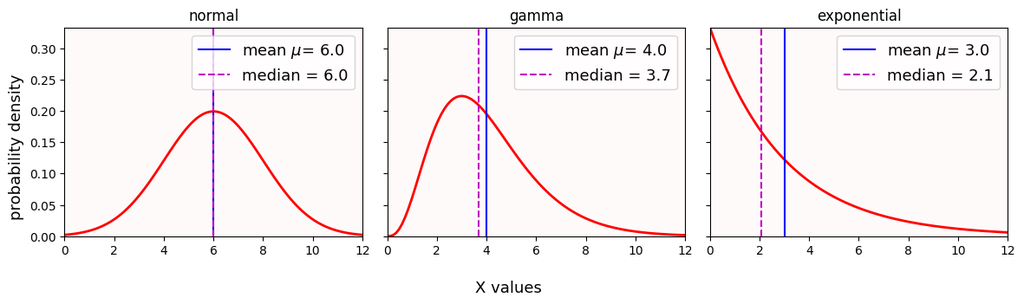

```python
# Establishing our synthetic data

import numpy as np
import matplotlib.pyplot as plt
from scipy import stats


fs = 13 # fontsize variable for the plots
xvals = np.linspace(0,12,100)

# SciPy stats come with a large number of probability distributions
# https://docs.scipy.org/doc/scipy/reference/generated/scipy.stats.rv_continuous.html
normal = stats.norm(6, scale=2)
gamma = stats.gamma(4, scale=1)
exponential = stats.expon(0, scale=3)

# Put the distributions in a dictionary so it is easier to loop later
distr = dict(normal=normal, gamma=gamma, exponential=exponential)

fig, ax = plt.subplots(1,len(distr),figsize=(12,3.5),sharex=True, sharey=True)
for i,key in enumerate(distr):
    ax[i].plot(xvals, distr[key].pdf(xvals), c='r', lw=2, zorder=1)
    ax[i].axvline(distr[key].mean(), c='b', ls='solid', label='mean $\\mu$' + '= {:.1f}'.format(distr[key].mean()), zorder=2)
    ax[i].axvline(distr[key].median(), c='m', ls='dashed', label='median = {:.1f}'.format(distr[key].median()), zorder=3)
    ax[i].legend(loc='upper right', fontsize=fs)
    ax[i].set_facecolor('snow')
    ax[i].set_title(key)
    ax[i].margins(0)
fig.supylabel('probability density', fontsize=fs)
fig.supxlabel('X values', fontsize=fs)
fig.tight_layout();
```

Ultimately, we'll see how the skewness can affect the Central Limit Theorem

### 1.1 Reminder of some mathematical concepts

Whenever we draw a sample of size $n$, we consider a set of $n$ measurements $x_1,x_2,\ldots,x_n$. From there, we can compute its **sample** mean $\bar\mu$ (or $\bar x$) and its **sample** population standard deviation $\bar\sigma$ (or $s$). Notice the bars on top.

$$\bar\mu = \frac{x_1+x_2+\ldots+x_n}n=\frac1n\sum_{i=1}^nx_i.$$

$$\bar\sigma = \sqrt{\frac{(x_1-\bar\mu)^2 +\ldots+ (x_n-\bar\mu)^2}{n-1}} = \sqrt{\frac1{n-1}\sum_{i=1}^n(x_i-\bar\mu)^2}.$$

These are the formulas you and Python have always been using.

## In real life, $\mu$ and $\sigma$ are unknown. We only have $\bar\mu$ and $\bar\sigma$ at our disposal. While similar, they are not the same. This distinction can have serious implications.

### 1.2 A note on Bessel's correction

In many textbooks you'll see that they use $\frac1n$ instead of $\frac1{n-1}$ for the sample standard deviation. We will use the $n-1$ formula, which is known as the [Bessel's correction](https://en.wikipedia.org/wiki/Bessel%27s_correction) and produces better results.

**Important**: SciPy and pandas apply Bessel's correction by default. NumPy does not, but we can force it by specifying the `ddof = 1` parameter.

## 2. The Law of Large Numbers (LLN)

For most of the datasets we have worked with so far, we take the mean of our experiment measurements as a first step to gauge how our data behaves. And means are not just for vibe checks. If you recall, whenever we have two different populations, the t-test is the check whether *the means* of these two populations are indeed statistically the same or not.

Think again of the hemp-fed cows and the 9-THC concentration in their livers:

The *population mean* $\mu$ would be the mean you get by measuring the livers of *all* the cows: past, present, and future, from Alaska to Patagonia. Obviously, it is impossible to calculate the exact $\mu$ value. We can only take a small number of cows and compute $\bar\mu$ instead.

Are $\mu$ and $\bar\mu$ close? Yes!

The **Law of Large Numbers** (LLN), in short, says that if we have larger and larger sample size (increasing $n$), then the sample mean will get closer and closer to the population mean.

**Watch the following video that explains the LLN visually.**

```python
from IPython.display import YouTubeVideo
YouTubeVideo("MntX3zWNWec",width=640,height=360)
```

[video not shown]

### 2.1 The fine print

LLN says that if we keep increasing our sample size, our measured mean will *eventually* match the population mean **as long as** two important conditions hold.

1. **Independence**: All samples must be independent from each other
   - For the THC concentration data, samples are independent because the cannabinoids going into one cow did not influence in any way the liver of another cow.
2. **Identical distribution:** All samples must come from the same population
   - All the cows used in the experiment were the same subspecies, age, upbringing, etc.
   - In other words, all external factors were accounted for, making all the cows essentially identical.

In math textbooks these two conditions are referred to as IID: Independent and Identically Distributed.

✅ **Question 1**

Think about the switchgrass yield experiment from last class. For 2017, $n=5$ switchgrass samples (plots) were collected at the Bradford Experimental Farm at MU. There was enough spacing between plots to avoid cross-pollination and other effects, as seen in [Figures 1c-d from Ricketts et al (2023)](https://onlinelibrary.wiley.com/cms/asset/2ce6244d-9659-43bb-9849-fb3c57715584/gcbb13046-fig-0001-m.jpg).

- Are the 2017 Missouri samples reasonably IID?

✎ *Put your answer here.*

### 2.2 Law of Large Numbers: simulated means

Below we do the following simulation:

1. Get a sample of size $n=5$ from each of the distributions from (1)
2. Compute the sample mean $\bar\mu$.
3. Repeat steps 1–2 increasing sample size $n$.

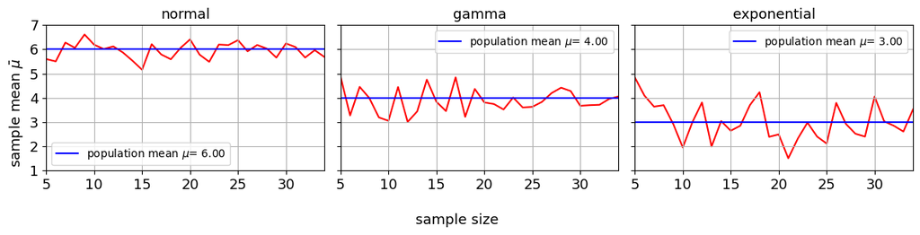

```python
# Sample mean vs population mean

rng = np.random.default_rng(seed=42)

fig, ax = plt.subplots(1,len(distr),figsize=(12,3),sharex=True, sharey=True)

for i,key in enumerate(distr):
    sample_mean = np.zeros(30)
    for n in range(5,len(sample_mean)+5):
        samples = distr[key].rvs(n, random_state=rng)
        sample_mean[n-5] = samples.mean()

    ax[i].plot(range(5,len(sample_mean)+5), sample_mean, c='r', zorder=1)
    ax[i].axhline(distr[key].mean(), c='b', ls='solid', label='population mean $\\mu$' + '= {:.2f}'.format(distr[key].mean()), zorder=2)
    ax[i].legend()
    ax[i].set_title(key, fontsize=fs)
    ax[i].margins(0)
    ax[i].set_xticks(range(5,len(sample_mean)+5,5), range(5,len(sample_mean)+5,5))
    ax[i].set_yticks(range(1,8), range(1,8))
    ax[i].grid()
    ax[i].tick_params(labelsize=fs)

fig.supylabel('sample mean $\\bar\\mu$', fontsize=fs)
fig.supxlabel('sample size', fontsize=fs)
fig.tight_layout();
```

✅ **Question 4**

- What do you notice in all three plots?
- Would $n=5$ be enough to get a reasonable estimate of the population mean? What about $n=10$ or $n=20$?
- Does it matter if my data comes from a symmetric or asymmetric distribution?
- Does the plot agree with the LLN? What if you change the `seed` of the random number generator `rng`?

✎ *Put your answer here.*

### 2.3 Law of Large Numbers: standard deviations

The LLM says that the sample mean will eventually match the population mean. But what about the standard deviations?

Let's repeat the simulation above but looking at the *sample standard deviation* each time.

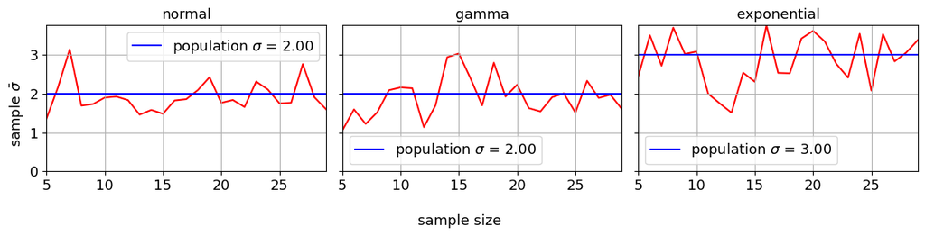

```python
# Sample mean vs population mean

rng = np.random.default_rng(2500)

fig, ax = plt.subplots(1,len(distr),figsize=(12,3),sharex=True, sharey=True)

for i,key in enumerate(distr):
    sample_sd = np.zeros(25)
    for n in range(5,len(sample_sd)+5):
        samples = distr[key].rvs(n, random_state=rng)
        sample_sd[n-5] = np.std(samples, ddof=1) #Applying Bessel's correction

    ax[i].plot(range(5,len(sample_sd)+5), sample_sd, c='r', zorder=1)
    ax[i].axhline(distr[key].std(), c='b', ls='solid', label='population $\\sigma$'+' = {:.2f}'.format(distr[key].std()), zorder=2)
    ax[i].legend(fontsize=fs)
    ax[i].set_title(key, fontsize=fs)
    ax[i].margins(0)
    ax[i].set_xticks(range(5,len(sample_sd)+2,5), range(5, len(sample_sd)+2, 5))
    ax[i].set_yticks(range(4), range(4))
    ax[i].grid()
    ax[i].tick_params(labelsize=fs)

fig.supylabel('sample $\\bar\\sigma$', fontsize=fs)
fig.supxlabel('sample size', fontsize=fs)
fig.tight_layout();
```

✅ **Question 5**

- Would $n=5$ be enough to get a reasonable estimate of the population standard deviation? What about $n=10$ or $n=20$?
- Does it matter if the data comes from a symmetric or asymmetric distribution?

✎ *Put your answer here.*

## 3. The Central Limit Theorem, revisited

The LLN tells us that the sample mean gets closer to the population mean as we increase the sample size. We can take that idea one step further with the CLT: the sample means follow a normal distribution (regardless of the underlying distribution) which gets tighter as the sample size increases.

More specifically, if we have a sample of size $n$, the sample mean $\bar\mu$ distributes as a normal of mean $\mu$ and standard deviation $\sigma/\sqrt{n}$:

$$\bar\mu \sim \mathcal{N}(\mu, \sigma/\sqrt n).$$

### 2.1 Simulations: distribution of sample means

Below we run the following simulation:

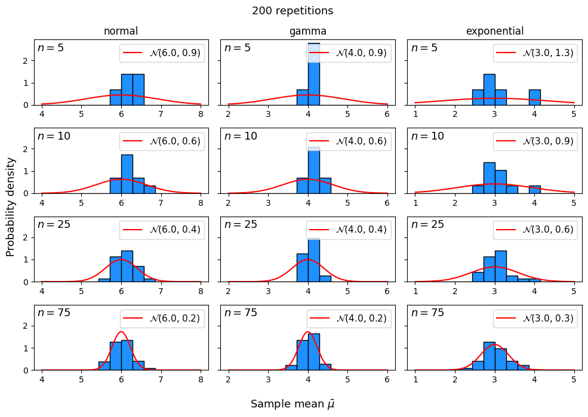

```python
# Make sure you understand how the plots reflect the CLT
# Notice that the CLT-related normal distribution gets tighter (SD decreases) as we increase sample size
N = 200
ns = [5, 10, 25, 75]
rng = np.random.default_rng(2500)

fig, ax = plt.subplots(len(ns), len(distr), figsize=(10, 7), sharex=False, sharey=True)
for i,key in enumerate(distr):

    samples = distr[key].rvs( (N, ns[-1]), random_state=rng)
    sample_means = samples.mean(axis = 1)
    bins = np.linspace(distr[key].mean() - 2, distr[key].mean() + 2, 15)
    x = np.linspace(bins[0], bins[-1], 250)
    ax[0,i].set_title(key)

    for j in range(len(ns)):
        norm = stats.norm.pdf(x, loc=distr[key].mean(), scale=distr[key].std()/np.sqrt(ns[j]) )
        ax[j,i].text(0.02,0.95,'$n={{{}}}$'.format(ns[j]), transform=ax[j,i].transAxes, ha='left', va='top', fontsize=fs)
        ax[j,i].hist(sample_means[:ns[j]], bins=bins, align='mid',
                     color='dodgerblue', edgecolor='k', density=True, zorder=2)
        ax[j,i].plot(x, norm, c='r', zorder=3,
                    label='$\\mathcal{N}$' + '({:.1f}, {:.1f})'.format(distr[key].mean(), distr[key].std()/np.sqrt(ns[j])))
        ax[j,i].legend(loc='upper right', fontsize=0.85*fs)

fig.supxlabel('Sample mean $\\bar\\mu$', fontsize=fs)
fig.supylabel('Probability density', fontsize=fs)
fig.suptitle('{} repetitions'.format(N), fontsize=fs)
fig.tight_layout();
```

✅ **Question 6**

Let's focus on the normal column (leftmost).

- What happens to the predicted normal curves (in red) as we increase the sample size $n$?
- What happens to the histogram of sample means (in blue) as we increase the sample size $n$?
- Does your previous two answers match the promise from the CLT?
- If for an experiment we collect $n=25$, will that be enough to trigger the CLT?

✎ *Put your answers here.*

✅ **Question 7**

Now let's focus on the other two columns, gamma and exponential. Remember that these are skewed distributions.

- How do they differ from your normal observations in Q6?
- If for an experiment we collect $n = 25$, will that be enough to trigger the CLT as well?

✎ *Put your answers here.*

✅ **Question 8**

Maybe the sample size $n$ is not a problem. Maybe the issue is that we are not taking enough repetitions.

- Re-run the code above but with larger `N` values (uppercase N).
- Do your answers for Q6 and Q7 change?

✎ *Put your answers here.*

✅ **Question 9**

The CLT says that things go normal as the *sample size* increases.

- Re-run the code above but with larger sample sizes, e.g. change `ns = [5, 10, 25, 75]` for `ns = [25, 75, 100, 200]`
- Do your answers for Q6 and Q7 remain consistent?

✎ *Put your answers here.*

## 4. Confidence Intervals, revisited

In the previous class we saw that one way to compute the 95% Confidence Interval is through the formula $$CI = \bar\mu \pm z_\alpha\times\frac\sigma{\sqrt{n}},$$ Where $z_\alpha$ is the appropriate quantile from the normal distribution $\mathcal{N}(0,1)$.

The formula is based on the CLT that says that $\bar\mu \sim \mathcal{N}(\mu,\sigma/\sqrt n)$. In other words, if we know the population mean and population standard deviation, we know how $\bar\mu$ behaves. But we don't know $\mu$ nor $\sigma$!

Thanks to the LLN, we can get away using the *sample* mean instead of the population mean. But we **cannot** have the same guarantees if we use the *sample* standard deviation instead of the *population* standard deviation. Especially if $n$ is small (which is often the case in biology-inspired experiments).

*To substitute, perchance to deviate: ay, there's the rub!*

### 4.1 Why does sample SD not cut it?

Below is the following simulation:

1. Consider the `key = 'normal'` distribution.
2. Draw a sample of size `n = 5`
3. Compute the sample mean $\bar\mu$ and sample SD $\bar\sigma$.
4. Use the sample SD to compute the 95% CI according to our formula
5. Check whether the confidence interval contains the actual population mean $\mu$ or not
6. Repeat steps 2–5 `N = 100` times

```
Intervals containing mu:	88 [88.0%]
Intervals not containing mu:	12 [12.0%]
```

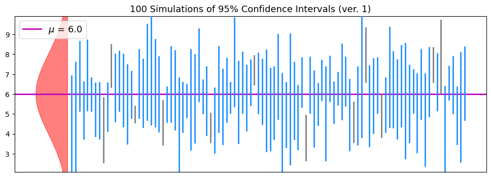

```python
# Draw N samples of size n each for the `key` distribution
N = 100
n = 5
key = 'normal'
#key = 'gamma'

# Compute the 95% CI for the mean
alpha = 0.95
z = stats.norm.ppf((1+alpha)/2)

fig, ax = plt.subplots(1,1,figsize=(12,4))
ax = np.atleast_1d(ax); i = 0
mu = distr[key].mean()
sigma = distr[key].std()

ax[i].fill_betweenx(xvals, -4*distr[key].pdf(xvals), 0, color='r', alpha=0.5, zorder=1)
ax[i].axhline(mu, c='m', lw=2, zorder=2, label='$\\mu$ ='+' {:.1f}'.format(mu) )
ax[i].legend(loc='upper left', fontsize=fs)
ax[i].tick_params(bottom=False, labelbottom=False)
ax[i].set_ylim( max([0, mu - z*sigma]), mu + z*sigma)

inside, outside = 0,0
for j in range(1,1+N):
    k = 0.1*j
    # Draw a sample of size n
    sample = distr[key].rvs(n)

    # Get its sample mean and SD
    sample_mean = sample.mean()
    sample_sd = sample.std(ddof=1)

    # Use CI with the sample SD
    ci_lower, ci_upper = (sample_mean - z*sample_sd/np.sqrt(n), sample_mean + z*sample_sd/np.sqrt(n))

    # Uncomment the line below using the population SD
    #ci_lower, ci_upper = (sample_mean - z*sigma/np.sqrt(n), sample_mean + z*sigma/np.sqrt(n))

    # Keep track on whether the interval contains indeed or not the population mean
    if (mu >= ci_lower) and (mu <= ci_upper):
        ax[i].plot([k,k], [ci_lower, ci_upper], c='dodgerblue', lw=2, zorder=3)
        inside += 1
    else:
        ax[i].plot([k,k], [ci_lower, ci_upper], c='gray', lw=2, zorder=3)
        outside += 1
ax[i].set_title('{} Simulations of {:.0f}% Confidence Intervals (ver. 1)'.format(N, alpha*100), fontsize=fs)
print('Intervals containing mu:\t{} [{:.1f}%]'.format(inside, inside/N*100))
print('Intervals not containing mu:\t{} [{:.1f}%]'.format(outside, outside/N*100))
```

✅ **Question 10**

Remember the definition of 95% CI: By repeating our sampling `N = 100` times, we expect that 95 (± change) of our CIs contain $\mu$.

- Do the confidence intervals behave as advertised?
- Is this a *consistent* behavior, ie., if you re-run the cell above—making new random numbers—do you get similar results?

*Note*: Wait at least 1 second between runs to make sure all the random numbers are new.

✎ *Explain your answer here.*

✅ **Question 11**

Maybe we got unlucky with our `N=100` repetitions.

- What if you increase the number of simulations to `N = 200`?
- Are our CIs working as advertised *consistently*? What are the sort of numbers you get when counting intervals containing $\mu$?

✎ *Put your answer here and explain.*

✅ **Question 12**

- What if we increase the sample size to `n = 15`? Are our CIs working as advertised *consistently*?
- What are the sort of numbers you get when counting intervals containing $\mu$?

✎ *Put your answers here.*

✅ **Question 13**

It seems that if we take `n=15` (or more) samples, the CI formula works as expected. But what if the data does not come from a symmetric distribution?

- Change `key = 'gamma'` so now the samples are drawn from a skewed distribution
- What sort of numbers do you get when counting intervals containing $\mu$?

✎ *Put your answers here.*

✅ **Question 14**

- Just like in Q12, now increase sample size yet again to `n = 30`
- Does that improve our CI results?

✎ *Put your answers here.*

✅ **Question 15**

- Set back `n = 5`
- Now uncomment the line:

```
ci_lower, ci_upper = (sample_mean - z*sigma/np.sqrt(n), sample_mean + z*sigma/np.sqrt(n))
```

- This way, we will compute the CIs with the *population* standard deviation instead of the *sample* one.
- Are our CIs working as advertised *consistently*? What are the sort of numbers you get when counting intervals containing $\mu$?

✎ *Put your answers here.*

✅ **Question 16: Summarizing your observations**

- What do you think is the relationship between sample size `n` and the skewness of the data?
- Put another way: what happens when data is skewed and sample size is small?
- For skewed data, how different are the CI results you get by using the population SD instead of the sample SD?
- Confirm your guess by drawing samples from an even more skewed distribution, `key = 'exponential'`

✎ *Put your answers here.*

## 5. The Student's t-distribution

From the simulation above, you might have observed that:

- Whenever using the sample SD $\bar\sigma$ instead of the population SD $\sigma$, the confidence intervals miss the mean $\mu$ at larger rates than expected.
- This error is aggravated if the data comes from a skewed distribution.
- This error can be fixed by either:
  - Increasing the sample size $n$.
  - Using $\sigma$ and not $\bar\sigma$.

The moral of the story is: just collect a lot of data and you'll be fine. **Case closed.**

**Except we cannot close the case.**

- In real life, we very rarely—if ever—know the population SD $\sigma$. So that "solution" is a non-starter. We only have the sample SD.
- More often than not, due to time/money/energy constraints, the "go collect more data" is not an option.

**Is there a third possible solution?** YES—KIND OF..

### 5.1 The *t*-distribution to the rescue!

We cannot use $\sigma$ as the CLT demands because in real life we don't have that number. So far we have been computing the CIs as $$CI_\alpha = \bar\mu \pm z_\alpha\times\frac{\bar\sigma}{\sqrt{n}}, \quad\text{(this formula does not always work in real life)}$$ with $z_\alpha$ the appropriate quantile from *a standard normal distribution*.

If you look at the gray CIs in our prior simulations (CIs that fail to contain $\mu$), notice that many of them would turn blue if they were stretched *a bit* more. If we have a large sample size $n$, we just need a little stretch. But if we have a small $n$, the stretch has to be a tad more generous.

In other words, instead of $z_\alpha$, we need quantiles $t_\alpha$ from a distribution that is *larger* than normal when $n$ is small. But this same distribution *is pretty much the normal* when $n$ is large.

**Such distribution is the Student's *t* !**

The standard Student's $t$ is symmetric, centered at 0, but it depends of a parameter known as *degrees of freedom*—$df$ for short. You'll see that $df$ is closely related to sample size $n$.

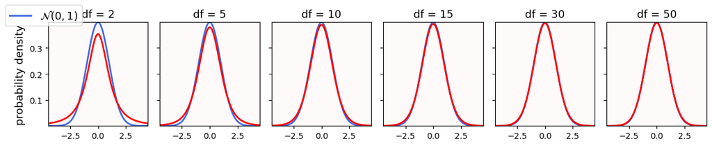

```python
# In red, we plot different Student's ts for different degrees of freedom
# In blue is the standard normal distribution

dfs = [2,5,10,15,30,50]

x = np.linspace(-4.5,4.5,250)
fig, ax = plt.subplots(1,len(dfs),figsize=(12,2.5),sharex=True, sharey=True)
for i in range(len(dfs)):
    ax[i].plot(x, stats.norm.pdf(x), c='royalblue', lw=2, label='$\mathcal{N}(0,1)$', zorder=1)
    ax[i].plot(x, stats.t.pdf(x, dfs[i]), c='r', lw=2, zorder=2)
    ax[i].set_facecolor('snow')
    ax[i].set_title('df = {}'.format(dfs[i]), fontsize=fs)
    ax[i].margins(0)
fig.legend(*ax[0].get_legend_handles_labels(), loc='upper left', fontsize=13)
fig.supylabel('probability density', fontsize=fs)

fig.tight_layout();
```

✅ **Question 17**

Above, the blue curve (standard normal curve) is the same in the six plots

- What do you notice about Student's $t$ as we increase its degrees of freedom?

✎ *Put your answers here.*

Formally speaking, we say the $t$ distribution has *heavier* tails, as the normal curve tends to taper off much quicker than the $t$, especially for low degrees of freedom.

### 5.2 Comparing normal and *t* quantiles

To compute the 95% CI ($\alpha = 0.95$), remember we needed the $(1+\alpha)/2 = 0.975$-th quantile of the standard normal distribution.

How does the $0.975$-th quantile of the $t$ distribution look like? Below we plot them for an increasing number of degrees of freedom.

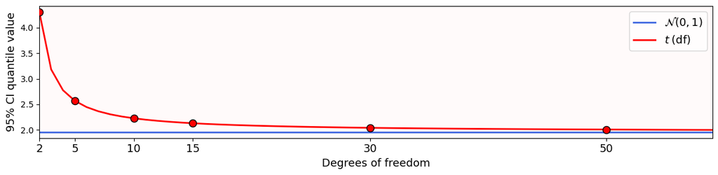

```python
# In blue is the normal quantile
# In red are the t quantiles
# The red circles emphasize the degrees of freedom we plotted above

alpha = 0.95
z = stats.norm.ppf((1+alpha)/2)

# A range of degrees of freedom and the corresponding quantiles
df = range(2,60)
ts = stats.t.ppf((1+alpha)/2, df)

fig, ax = plt.subplots(1,1,figsize=(12,3),sharex=True, sharey=True)
ax = np.atleast_1d(ax).ravel(); i = 0

ax[i].axhline(z, c='royalblue', lw=2, label='$\mathcal{N}(0,1)$', zorder=1)
ax[i].plot(df , ts, c='r', lw=2, zorder=2, label='$t\;$(df)')
ax[i].scatter(dfs, stats.t.ppf((1+alpha)/2, dfs), c='r', ec='k', marker='o', s=75, zorder=3)
ax[i].set_facecolor('snow')
ax[i].margins(x=0)
ax[i].set_xticks(dfs, dfs, fontsize=fs)
ax[i].legend(loc='upper right', fontsize=fs)
ax[i].set_ylabel('{:.0f}% CI quantile value'.format(100*alpha), fontsize=fs)
ax[i].set_xlabel('Degrees of freedom', fontsize=fs)
fig.tight_layout();
```

✅ **Question 18**

- What do you notice about Student's $t$ $0.975$-the quantile as we increase its degrees of freedom?
- Does your observations here match with Q17?

✎ *Put your answers here.*

### 5.3 Confidence Intervals, recomputed

We are finally able to check the revised formula for confidence intervals: $$CI_\alpha = \bar\mu\pm t_{\alpha, n-1}\times\frac{\bar\sigma}{\sqrt n}.$$ We are going to use the quantiles from a $t$ distribution with $n-1$ degrees of freedom instead of the normal.

- As you have observed before, our CIs tend to be more inaccurate when we have small sample sizes $n$. We have the following logic:
- Small sample size $n$
  - → small degree of freedom
    - → heavy tail for the $t$ distribution
      - → the $0.975$-th quantile value is much larger for $t$ than for the normal curve
        - → the confidence interval is stretched more to account for not knowing $\sigma$, the population SD.
- If the sample size is large
  - → a large degree of freedom
    - → the $t$ distribution is almost identical to the normal
      - → there is no need to stretch further the confidence intervals.

Below is the same simulation as in (4.1), except that we use $t$ quantiles instead.

```
Intervals containing mu:	97 [97.0%]
Intervals not containing mu:	3 [3.0%]
```

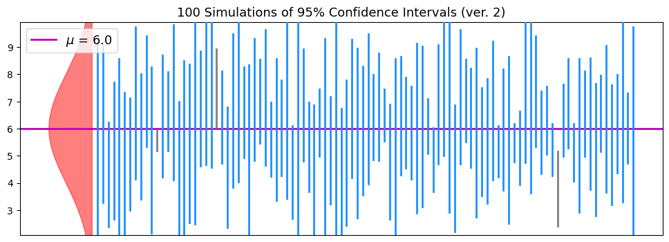

```python
# Draw N samples of size n each for the `key` distribution
N = 100
n = 5
key = 'normal'
#key = 'gamma'

# Compute the 95% CI for the mean using a t distribution with `n-1` degrees of freedom
alpha = 0.95
t = stats.t.ppf((1+alpha)/2, n-1)

fig, ax = plt.subplots(1,1,figsize=(12,4))
ax = np.atleast_1d(ax); i = 0
mu = distr[key].mean()
sigma = distr[key].std()

ax[i].fill_betweenx(xvals, -4*distr[key].pdf(xvals), 0, color='r', alpha=0.5, zorder=1)
ax[i].axhline(mu, c='m', lw=2, zorder=2, label='$\\mu$ ='+' {:.1f}'.format(mu) )
ax[i].legend(loc='upper left', fontsize=fs)
ax[i].tick_params(bottom=False, labelbottom=False)
ax[i].set_ylim( max([0, mu - z*sigma]), mu + z*sigma)

inside, outside = 0,0
for j in range(1,1+N):
    k = 0.1*j
    # Draw a sample of size n
    sample = distr[key].rvs(n)

    # Get its sample mean and SE = SD/sqrt(n)
    sample_mean = sample.mean()
    sample_sem = stats.sem(sample)

    # Use CI with the sample SD but t quantile
    ci_lower, ci_upper = (sample_mean - t*sample_sem, sample_mean + t*sample_sem)

    # Keep track on whether the interval contains indeed or not the population mean
    if (mu >= ci_lower) and (mu <= ci_upper):
        ax[i].plot([k,k], [ci_lower, ci_upper], c='dodgerblue', lw=2, zorder=3)
        inside += 1
    else:
        ax[i].plot([k,k], [ci_lower, ci_upper], c='gray', lw=2, zorder=3)
        outside += 1
ax[i].set_title('{} Simulations of {:.0f}% Confidence Intervals (ver. 2)'.format(N, alpha*100), fontsize=fs)
print('Intervals containing mu:\t{} [{:.1f}%]'.format(inside, inside/N*100))
print('Intervals not containing mu:\t{} [{:.1f}%]'.format(outside, outside/N*100))
```

✅ **Question 19**

- Drawing samples of size `n = 5` from the `'normal'` distribution, does the $t$ correction improve our results?
- Is it likely that now 95% of our confidence intervals contain $\mu$ on a consistent manner?

✎ *Put your answers here.*

✅ **Question 20**

What about skewed data?

- Drawing samples of size `n = 5` from the `'gamma'` distribution, does the $t$ correction improve our results?
- What about using `n = 10` instead?

✎ *Put your answers here.*

## 6. The bottom line

On whether to use $z$ vs $t$ quantiles (first vs second CI formula), it boils down to an educated choice that depends on

- How large is your sample size $n$
- How skewed is your data

|  | Data is symmetric | Data is somewhat skewed |
| --- | --- | --- |
| **Sample size $n$ is large** | Choice does not matter | Choice does not matter (but go with $t$ to be safe) |
| **Sample size $n$ is small** | Use $t$ quantiles | $t$ is a *not thaaat* bad of choice |

If your data is noticeably skewed and your sample size is particularly small, then the $t$ quantiles will not fix your problems.

Hope is not totally lost, but you'll have to be much more careful on how you analyze such data. The techniques involved often rely on additional information, like "Do you have a good guess on what the underlying distribution might be?" and/or you have get creative with bootstrapping.

### Assignment wrap-up

Please fill out form from the link below. You must log-in using your MU credentials. **You must completely fill this out in order to receive credit for the assignment!**

#### https://forms.office.com/r/37zmzq3PT8

```python
# Click on the link above if this cell fails to produce a survey form.

from IPython.display import HTML
HTML(
"""
<iframe
	src="https://forms.office.com/r/37zmzq3PT8"
	width="800px"
	height="600px"
	frameborder="0"
	marginheight="0"
	marginwidth="0">
	Click the link above if this cell fails to produce a survey
</iframe>
"""
)
```

[interactive chart not shown]

### Congratulations, you're done!

Submit this assignment by uploading it to the course Canvas web page. Go to the "Pre-class assignments" folder, find the appropriate submission folder link, and upload it there.

See you in class!

© Copyright 2026, Division of Plant Science & Technology—University of Missouri